# Presentation

Nate Schambach

2022-03-03

```r
team_totals <- read.csv("C:/Users/natha/OneDrive/Desktop/Southern/Spring 22/Math 326/Presentation/team_totals.csv", stringsAsFactors=TRUE)
summary(team_totals)
```

```
##      Season     League                      Team      Abreviation
##  Min.   :1980   NBA:1237   Atlanta Hawks      : 43   ATL    : 43
##  1st Qu.:1992              Boston Celtics     : 43   BOS    : 43
##  Median :2002              Chicago Bulls      : 43   CHI    : 43
##  Mean   :2002              Cleveland Cavaliers: 43   CLE    : 43
##  3rd Qu.:2013              Denver Nuggets     : 43   DEN    : 43
##  Max.   :2022              Detroit Pistons    : 43   (Other):979
##                            (Other)            :979   NA's   : 43
##   Playoffs           Games             MP              FG            FGA
##  Mode :logical   Min.   :50.00   Min.   :12025   Min.   :1539   Min.   :3561
##  FALSE:581       1st Qu.:82.00   1st Qu.:19755   1st Qu.:2944   1st Qu.:6498
##  TRUE :656       Median :82.00   Median :19805   Median :3108   Median :6793
##                  Mean   :79.77   Mean   :19281   Mean   :3107   Mean   :6715
##                  3rd Qu.:82.00   3rd Qu.:19855   3rd Qu.:3352   3rd Qu.:7122
##                  Max.   :82.00   Max.   :20080   Max.   :3980   Max.   :8868
##
##    FG_Percent         X3P              X3PA       X3P_Percent
##  Min.   :0.401   Min.   :  10.0   Min.   :  75   Min.   :0.1040
##  1st Qu.:0.447   1st Qu.: 208.0   1st Qu.: 630   1st Qu.:0.3230
##  Median :0.461   Median : 426.0   Median :1209   Median :0.3470
##  Mean   :0.462   Mean   : 431.4   Mean   :1226   Mean   :0.3342
##  3rd Qu.:0.475   3rd Qu.: 610.0   3rd Qu.:1670   3rd Qu.:0.3630
##  Max.   :0.545   Max.   :1323.0   Max.   :3721   Max.   :0.4280
##
##       X2P            X2Pa       X2P_Percent           FT            FTA
##  Min.   :1327   Min.   :2745   Min.   :0.4210   Min.   : 745   Min.   :1077
##  1st Qu.:2388   1st Qu.:4890   1st Qu.:0.4720   1st Qu.:1400   1st Qu.:1850
##  Median :2566   Median :5359   Median :0.4870   Median :1546   Median :2067
##  Mean   :2676   Mean   :5489   Mean   :0.4883   Mean   :1544   Mean   :2044
##  3rd Qu.:3104   3rd Qu.:6402   3rd Qu.:0.5030   3rd Qu.:1716   3rd Qu.:2280
##  Max.   :3954   Max.   :7873   Max.   :0.5710   Max.   :2388   Max.   :3051
##
##    FT_Percent          ORb              DRb            TRb            ASST
##  Min.   :0.6600   Min.   : 472.0   Min.   :1293   Min.   :1788   Min.   : 782
##  1st Qu.:0.7380   1st Qu.: 849.0   1st Qu.:2344   1st Qu.:3326   1st Qu.:1708
##  Median :0.7570   Median : 980.0   Median :2450   Median :3469   Median :1845
##  Mean   :0.7557   Mean   : 980.2   Mean   :2436   Mean   :3416   Mean   :1851
##  3rd Qu.:0.7750   3rd Qu.:1114.0   3rd Qu.:2563   3rd Qu.:3603   3rd Qu.:2025
##  Max.   :0.8390   Max.   :1520.0   Max.   :3316   Max.   :4078   Max.   :2575
##
##      Steal          Block            Tov             PF            PTS
##  Min.   : 316   Min.   :169.0   Min.   : 641   Min.   : 935   Min.   : 4095
##  1st Qu.: 576   1st Qu.:348.0   1st Qu.:1132   1st Qu.:1640   1st Qu.: 7872
##  Median : 639   Median :397.0   Median :1226   Median :1786   Median : 8271
##  Mean   : 641   Mean   :403.3   Mean   :1233   Mean   :1770   Mean   : 8189
##  3rd Qu.: 705   3rd Qu.:452.0   3rd Qu.:1347   3rd Qu.:1939   3rd Qu.: 8734
##  Max.   :1053   Max.   :716.0   Max.   :1873   Max.   :2432   Max.   :10371
##
```

```r
attach(team_totals)
```

### FG vs 3PA

Outliers at .401 and .545, but shouldn’t affect the graph due to the number of data points. The slope is very small, only -0.0000106. Which means for ever 1 three pointer attempted the FG percentage goes down by the previously stated amount. The coeffient determinant is 0.1378 which means 13.78% of the sample variation in FG percentage is explained by three pointers attempted. We are 95% sure the slope is somewhere between -0.0000091 and -0.000012 The data is showing a very small amount of impact but it is negative which means we cannot disregard that the number of threes attempted having an impact on the field goal percentage .

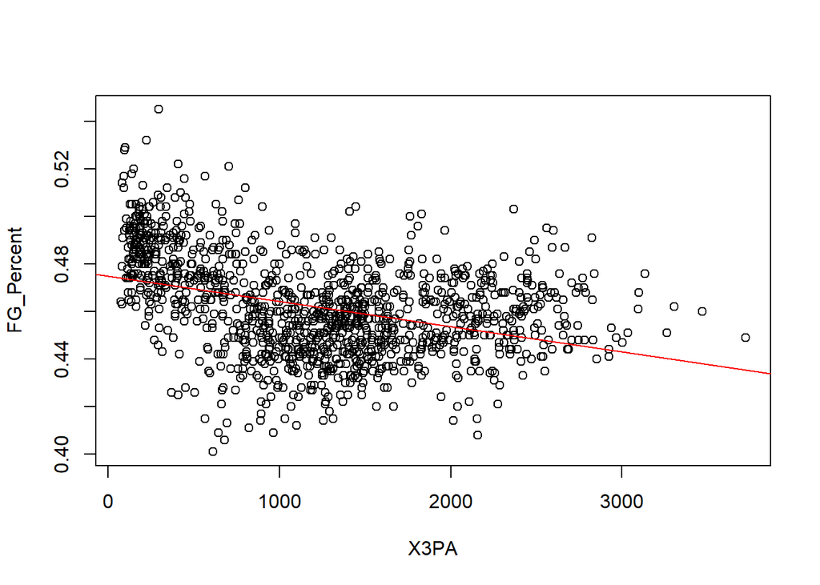

```r
lmfg=lm(FG_Percent~X3PA)
plot(FG_Percent~X3PA)
abline(lmfg,col="red")
```

```r
slmfg=summary(lmfg)
slmfg
```

```
##
## Call:
## lm(formula = FG_Percent ~ X3PA)
##
## Residuals:
##       Min        1Q    Median        3Q       Max
## -0.067472 -0.012416 -0.000164  0.013517  0.073165
##
## Coefficients:
##               Estimate Std. Error t value Pr(>|t|)
## (Intercept)  4.750e-01  1.077e-03  441.15   <2e-16 ***
## X3PA        -1.061e-05  7.553e-07  -14.05   <2e-16 ***
## ---
## Signif. codes:  0 '***' 0.001 '**' 0.01 '*' 0.05 '.' 0.1 ' ' 1
##
## Residual standard error: 0.01933 on 1235 degrees of freedom
## Multiple R-squared:  0.1378, Adjusted R-squared:  0.1371
## F-statistic: 197.3 on 1 and 1235 DF,  p-value: < 2.2e-16
```

```r
codfg=slmfg$r.squared
codfg
```

```
## [1] 0.1377783
```

```r
cifg=confint(lmfg,'X3PA',.95)
cifg
```

```
##              2.5 %        97.5 %
## X3PA -1.209263e-05 -9.128918e-06
```

### FG vs Season

There are the same outliers as the last graph because FG_Percentage is the response variable again, but again it shouldn’t affect the graph due to the number of data points. The slope is very small, only -0.00078. Which means for ever 1 season the FG percentage goes down by the previously stated amount. The coeffient determinant is 0.2078 which means 20.78% of the sample variation in FG percentage is explained by the season it was played in. We are 95% sure the slope is somewhere between -.00070 and -.00087. The data is showing a very small amount of impact but it is negative which means again we cannot disregard that the number of seasons played has an impact on the field goal percentage.

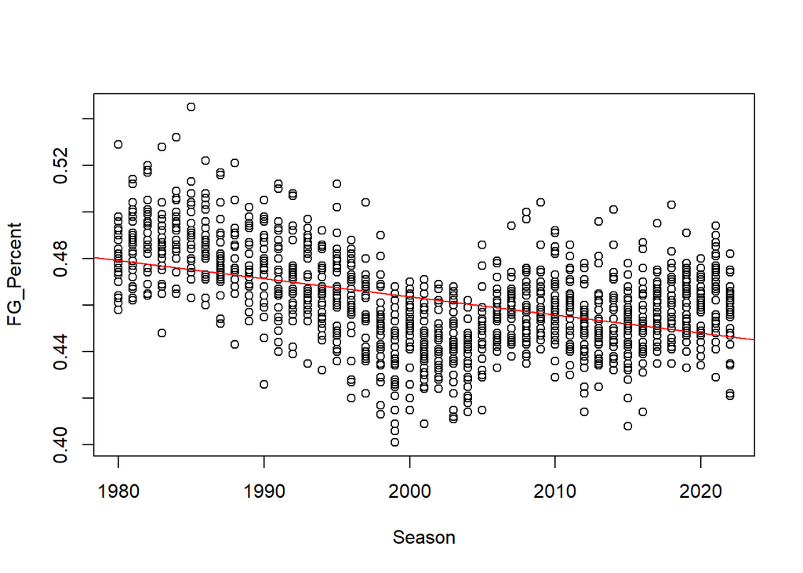

```r
lms=lm(FG_Percent~Season)
plot(FG_Percent~Season)
abline(lms,col="red")
```

```r
slms=summary(lms)
slms
```

```
##
## Call:
## lm(formula = FG_Percent ~ Season)
##
## Residuals:
##       Min        1Q    Median        3Q       Max
## -0.063349 -0.012085  0.000288  0.012915  0.069728
##
## Coefficients:
##               Estimate Std. Error t value Pr(>|t|)
## (Intercept)  2.024e+00  8.679e-02   23.32   <2e-16 ***
## Season      -7.803e-04  4.335e-05  -18.00   <2e-16 ***
## ---
## Signif. codes:  0 '***' 0.001 '**' 0.01 '*' 0.05 '.' 0.1 ' ' 1
##
## Residual standard error: 0.01853 on 1235 degrees of freedom
## Multiple R-squared:  0.2078, Adjusted R-squared:  0.2072
## F-statistic:   324 on 1 and 1235 DF,  p-value: < 2.2e-16
```

```r
cods=slms$r.squared
cods
```

```
## [1] 0.2078058
```

```r
cis=confint(lms,'Season',.95)
cis
```

```
##                2.5 %        97.5 %
## Season -0.0008653022 -0.0006952064
```

### 3PA vs Season

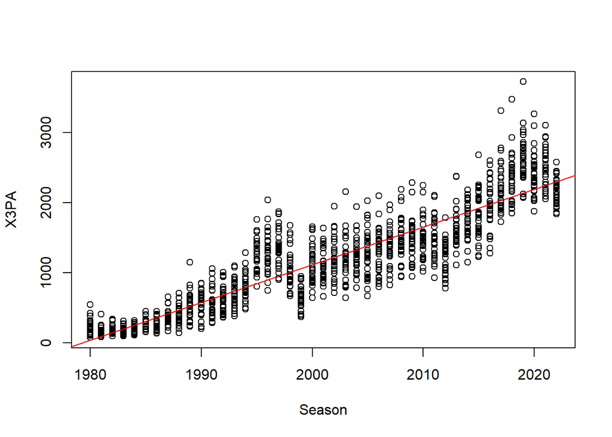

```r
lm3PA=lm(X3PA~Season)
plot(X3PA~Season)
abline(lm3PA,col="red")
```

```r
slm3PA=summary(lm3PA)
slm3PA
```

```
##
## Call:
## lm(formula = X3PA ~ Season)
##
## Residuals:
##     Min      1Q  Median      3Q     Max
## -983.05 -190.74  -22.58  168.36 1584.59
##
## Coefficients:
##               Estimate Std. Error t value Pr(>|t|)
## (Intercept) -1.064e+05  1.501e+03  -70.89   <2e-16 ***
## Season       5.377e+01  7.498e-01   71.71   <2e-16 ***
## ---
## Signif. codes:  0 '***' 0.001 '**' 0.01 '*' 0.05 '.' 0.1 ' ' 1
##
## Residual standard error: 320.5 on 1235 degrees of freedom
## Multiple R-squared:  0.8064, Adjusted R-squared:  0.8062
## F-statistic:  5143 on 1 and 1235 DF,  p-value: < 2.2e-16
```

```r
cod3PA=slm3PA$r.squared
cod3PA
```

```
## [1] 0.806355
```

```r
ci3PA=confint(lm3PA,'Season',.95)
ci3PA
```

```
##           2.5 %   97.5 %
## Season 52.29581 55.23769
```

### Residuals Analysis

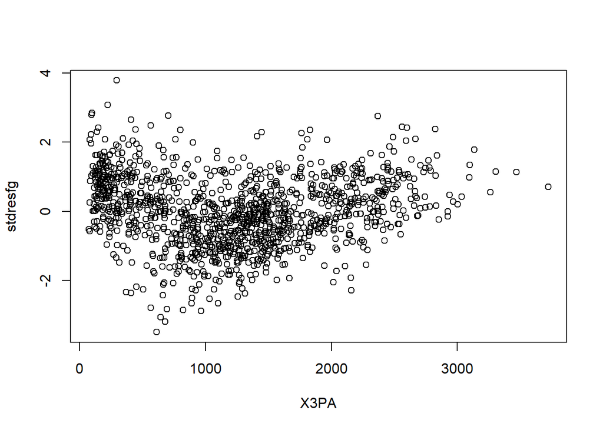

```r
stdresfg=rstandard(lmfg)
plot(X3PA,stdresfg)
```

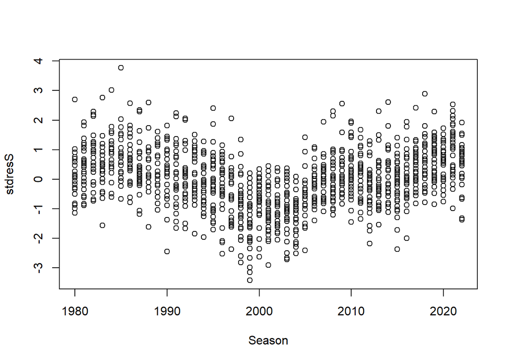

```r
stdresS=rstandard(lms)
plot(Season,stdresS)
```

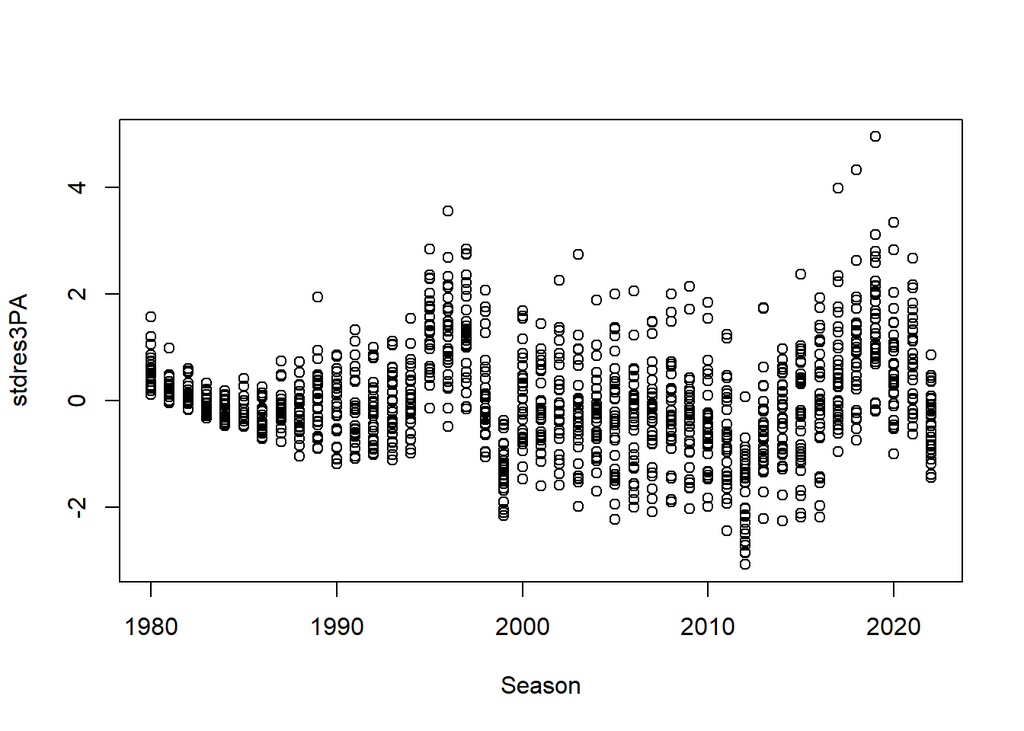

```r
stdres3PA=rstandard(lm3PA)
plot(Season,stdres3PA)
```

### Sample vs Theoretical

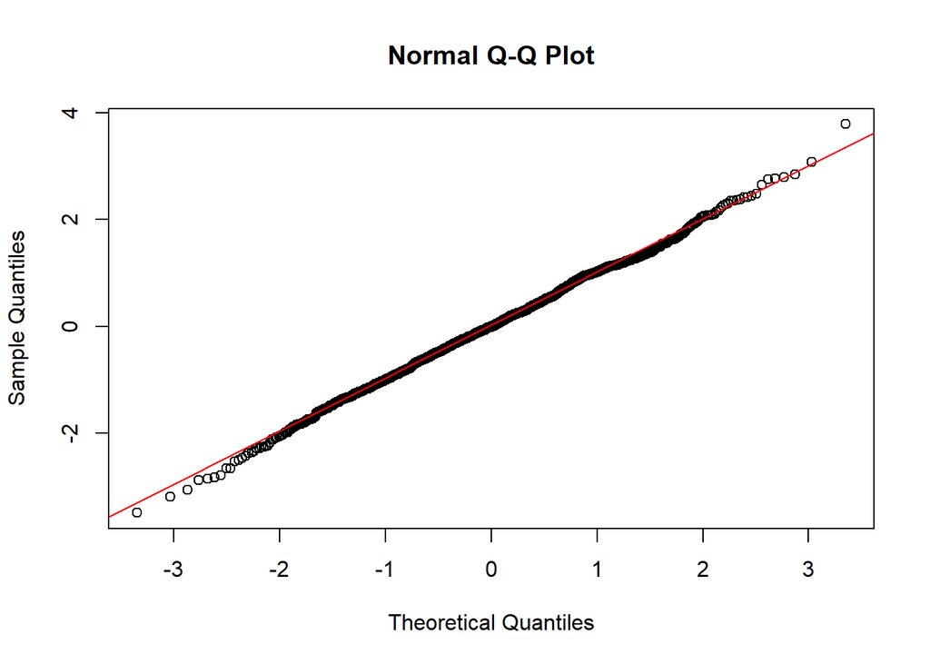

```r
qqnorm(stdresfg)
qqline(stdresfg,col="red")
```

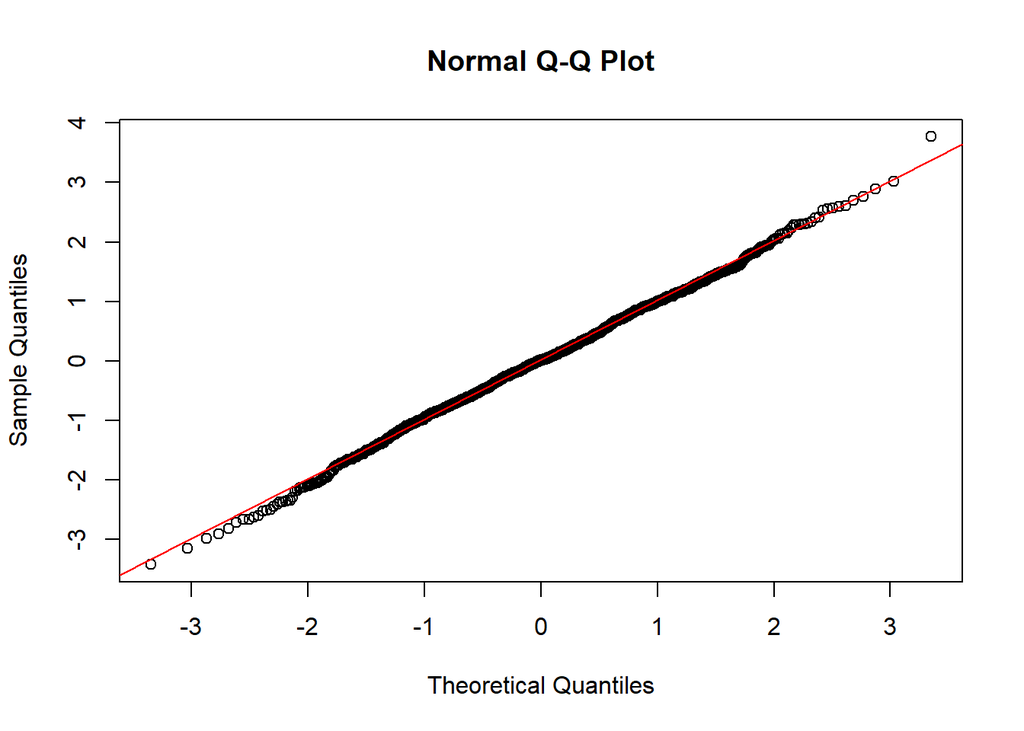

```r
qqnorm(stdresS)
qqline(stdresS,col="red")
```

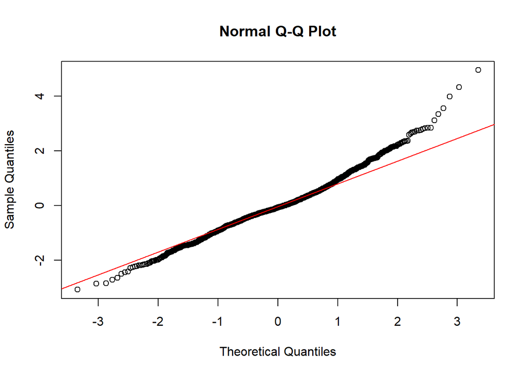

```r
qqnorm(stdres3PA)
qqline(stdres3PA,col="red")
```